# Quantified Self Movement Data Analysis

Ion Suruceanu

November 20, 2015

### Executive Summary

Using devices such as Jawbone Up, Nike FuelBand, and Fitbit it is now possible to collect a large amount of data about personal activity relatively inexpensively. These type of devices are part of the quantified self movement - a group of enthusiasts who take measurements about themselves regularly to improve their health, to find patterns in their behavior, or because they are tech geeks. One thing that people regularly do is quantify how much of a particular activity they do, but they rarely quantify how well they do it.

The aim of this analysis was to use data colected from accelerometers placed on the belt, forearm, arm, and dumbell of six participants to predict how well they were doing the exercise in terms of the classification in the data.

### Getting and cleaning data

Libraries were loaded in the backgroung

Loading *project.R* file which contains constants and functions for data loading.

```r
source("project.R")

file.download(plm.training.url, plm.training.csv)
file.download(plm.testing.url, plm.testing.csv)

trainingRaw <- read.csv(plm.training.csv,  na.strings= c("NA",""," "))
testingRaw <- read.csv(plm.testing.csv,  na.strings= c("NA",""," "))

dim(trainingRaw)
```

```
## [1] 19622   160
```

```r
dim(testingRaw)
```

```
## [1]  20 160
```

```r
trainingRaw <- trainingRaw[, colSums(is.na(trainingRaw)) == 0]
testingRaw <- testingRaw[, colSums(is.na(testingRaw)) == 0]

training <- trainingRaw[8:length(trainingRaw)]
testing <- testingRaw[8:length(testingRaw)]
```

We will split the cleaned *training* data set in training and validation sets in a 70:30 ratio to train the model and then test it against data it was not specifically fitted to.

```r
set.seed(171615) # set random number generator seed for reproducibile purpose

inTrain <- createDataPartition(training$classe, p=0.7, list=F)
training.data <- training[inTrain, ]
training.validation <- training[-inTrain, ]
```

### Exploratory data

Figure bellow plots the correlations between features.

```r
dim(training.data)
```

```
## [1] 13737    53
```

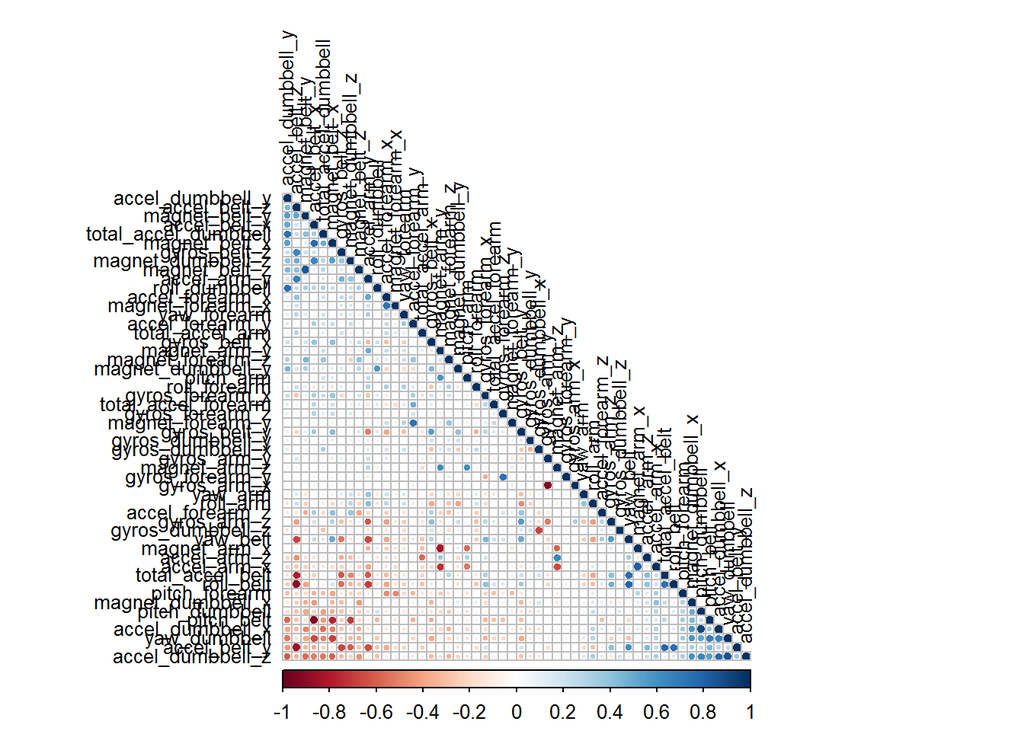

```r
cplot <- cor(training.data[sapply(training.data, is.numeric)],use="pairwise", method="spearman")
corrplot(cplot, order = "FPC", method="circle", type="lower", tl.cex=0.8,tl.col=rgb(0, 0, 0))
```

Red and blue colours indicate a highly negative and positive relationship respectively between the variables.

### Data modeling

In this analysis we will try to fit two models: *Boosting Tree*: its combines weak learners into a single strong learner, in an iterative fashion. It is easiest to explain in the least-squares regression setting, where the goal is to learn a model. *Random Forest*: it automatically selects important variables and is robust to correlated covariates & outliers in general. 5-fold is used for cross validation when applying the algorithm.

At the end we will compare the results of two and the best one will be selected.

```r
control <- trainControl(method = "cv", 5)
model.Rf <- train(classe ~ ., data = training.data, method = "rf", trControl=control, ntree=250)
model.Bt <- train(classe ~ ., training.data, method = "gbm", verbose = F, trControl=control)

predict.Rf <- predict(model.Rf, training.validation)
predict.Bt <- predict(model.Bt, training.validation)

confusion.Rf <- confusionMatrix(predict.Rf, training.validation$classe)
confusion.Bt <- confusionMatrix(predict.Bt, training.validation$classe)

confusion.Rf$overall["Accuracy"]
```

```
##  Accuracy
## 0.9932031
```

```r
confusion.Bt$overall["Accuracy"]
```

```
##  Accuracy
## 0.9571793
```

The Accuracy of the Random Forest is 99.32% which is begger then Boosting Tree with an Accuracy of 95.72%

So Random forest model proved very robust and adequete to predict new data.

### Predictions

Now the model will be applyed for testing data in *testing* data.frame to predict 20 unseen results of new data.

```r
predict.testing <- predict(model.Rf, testing)
predict.testing
```

```
##  [1] B A B A A E D B A A B C B A E E A B B B
## Levels: A B C D E
```

At the end will save the predicted values to own file of each 20 results.

```r
pml_write_files(predict.testing)
```

### Conclusions

Boosting Tree training is very slow and perform a little bit worse than Random Forest which ran about 4 times faster and with an Accuracy of 99.32%. So for final prediction for testing data Random Forest was selected.